# Evolutionary and ecological insights from herbicide‐resistant weeds: what have we learned about plant adaptation, and what is left to uncover? - Baucom - 2019 - New Phytologist - Wiley Online Library

[New Phytologist](https://nph.onlinelibrary.wiley.com/journal/14698137)

[Volume 223, Issue 1](https://nph.onlinelibrary.wiley.com/toc/14698137/2019/223/1) p. 68-82

[figure not shown]

Tansley review

Free Access

# Evolutionary and ecological insights from herbicide-resistant weeds: what have we learned about plant adaptation, and what is left to uncover?

[Regina S. Baucom](https://nph.onlinelibrary.wiley.com/action/doSearch?ContribAuthorRaw=Baucom%2C+Regina+S),

First published: 01 February 2019

https://doi.org/10.1111/nph.15723

Citations: 71

## Summary

The evolution of herbicide resistance in crop weeds presents one of the greatest challenges to agriculture and the production of food. Herbicide resistance has been studied for more than 60 yr, in the large part by researchers seeking to design effective weed control programs. As an outcome of this work, various unique questions in plant adaptation have been addressed. Here, I collate recent research on the herbicide-resistant problem in light of key questions and themes in evolution and ecology. I highlight discoveries made on herbicide-resistant weeds in three broad areas – the genetic basis of adaptation, evolutionary constraints, experimental evolution – and similarly discuss questions left to be answered. I then develop how one would use herbicide-resistance evolution as a model for studying eco-evolutionary dynamics within a community context. My overall goals are to highlight important findings in the weed science literature that are relevant to themes in plant adaptation and to stimulate the use of herbicide-resistant plants as models for addressing key questions within ecology and evolution.

| Contents |  |  |
| --- | --- | --- |
|  | Summary | 68 |
| I. | Introduction | 68 |
| II. | Genetic basis of adaptation | 69 |
| III. | Fitness costs and life-history trade-offs | 71 |
| IV. | Assessing selection via experimental evolution | 74 |
| V. | Eco-evolutionary dynamics: a developing framework | 76 |
| VI. | Conclusion | 77 |
|  | Acknowledgements | 78 |
|  | References | 79 |

## I. Introduction

Weeds are the most problematic organisms in agricultural areas (Oerke, 2005), costing > US$26 billion per year in yield reductions (Pimentel *et al*., 2000), and an additional US$7 billion on herbicide control (Gianessi & Reigner, 2007). An unfortunate outcome of the reliance on herbicides is the evolution of herbicide resistance in weeds, as a once susceptible population is no longer controlled by a particular herbicide. Herbicide resistance was first predicted by the ecologist J.L. Harper in 1956 (Harper, 1956) and identified soon afterwards in Hawaiian sugarcane plantations (Hilton, 1957). Following this, cases of resistance to the triazine herbicides were observed among crop weeds such as *Senecio vulgaris* and *Convolvulus arvensis* (Derscheid *et al*., 1970; Ryan, 1970). Herbicide resistance has since evolved many times across a variety of plants: currently, 245 species from 136 genera and 30 families are considered to be resistant to herbicides (Heap, 2018). Numerous distantly related species exhibit resistance to the same class of herbicide (Heap, 2018) and, while the same genetic and physiological mechanisms can underlie resistance to the same herbicide among species, this is not always the case (Délye *et al*., 2013a; Baucom, 2016).

Researchers have therefore studied herbicide resistance at the phenotypic, physiological, and genetic levels for roughly 60 yr, often with the dual aims of diagnosing the scale of the resistance problem and the development of strategies that help to delay its evolution and spread. As an outcome of this work, striking discoveries have been made about plant adaptation – ranging from identifying the genes and mutations responsible for resistance (Powles & Yu, 2010; Délye *et al*., 2013a), to understanding the prevalence of fitness costs associated with resistance (Vila-Aiub *et al*., 2009, 2011; Cousens & Fournier-Level, 2018), to making critical discoveries about how variable selection regimes may influence the evolution of resistance (Neve & Powles, 2005b; Vogwill *et al*., 2012; Lagator *et al*., 2014). This work – often found within the weed science literature – addresses themes that have long been at the forefront of evolution and ecology. These discoveries, however, have yet to be comprehensively synthesized in light of both current and emerging topics in ecology and evolution.

Furthermore, the wealth of knowledge gained on the resistance problem within the last 60 yr − largely due to the efforts of weed biologists − has positioned herbicide-resistant weeds as models for understanding rapid adaptation to human-mediated regimes of selection, as well as model species in evolution and ecology more broadly. There are a number of reasons why the phenomenon of herbicide resistance provides unique and highly relevant models for addressing questions in plant adaptation. Some reasons have to do with the ease of experimentation: resistance evolves rapidly in field populations (Holt & LeBaron, 1990), the selective agent is known, and multiple natural populations found in widely separated areas are repeatedly exposed to the same strong agent of selection (Baucom, 2016). Another reason − and one that has received less attention − is the synthetic, whole-organismal nature of weed science investigations more generally. For example, researchers studying the resistance problem will examine the phenotype by diagnosing the scale and extent of resistance among natural populations (Menchari *et al*., 2006; Kuester *et al*., 2015; Okada *et al*., 2015; Délye *et al*., 2016; Hicks *et al*., 2018), and will often pair this with a marker-assisted assessment of genetic differentiation and diversity to examine the likelihood that resistance alleles may migrate between areas via gene flow (Menchari *et al*., 2007; Okada *et al*., 2013, 2015; Kuester *et al*., 2015; Délye *et al*., 2016). Furthermore, and often within the same herbicide-resistant species, researchers will investigate the genetic control of resistance (Délye, 2005; Powles & Preston, 2006; Délye *et al*., 2013a, 2016; Okada & Jasieniuk, 2014; Scarabel *et al*., 2015) – whether it is controlled by a single locus or is polygenic – and will similarly identify both the genetic and physiological mechanism(s) responsible for resistance (reviewed in Powles & Yu, 2010; Délye *et al*., 2013a). As an outcome of these highly interdisciplinary, synthetic studies, weed scientists have generated enviable models for studying the adaptive process. What lessons have we learned about plant adaptation, and evolution and ecology, along the way? What emergent topics within evolution and ecology are we now uniquely poised to address using herbicide-resistant weeds?

Here, I collate recent research on the herbicide resistance problem in light of key questions and themes in evolution and ecology. I similarly present emerging topics in evolution and ecology for which the phenomenon of herbicide resistance provides an excellent model system, and discuss the frameworks in which adaptation to herbicide has been and can be examined. More specifically, I first present discoveries made on herbicide-resistant weeds in three areas broadly of interest to ecologists and evolutionary biologists – the genetic basis of adaptation, evolutionary constraints (fitness costs and life-history trade-offs), and experimental evolution. Within each topic, I address the following: What have we learned about these broad areas from studies of herbicide-resistant weeds? What questions within each topic would the phenomenon of herbicide resistance provide useful models? I then discuss contributions that herbicide resistance can add to the developing study of eco-evolutionary dynamics within a community context. My overall goal is to highlight important findings in the weed science literature that are relevant to current and emerging themes in plant adaptation and to stimulate the development of novel hypotheses of interest to both evolutionary biologists and weed scientists.

## II. Genetic basis of adaptation

A major goal of evolutionary biology is to understand how biodiversity is created and maintained in nature (Lewontin, 1974). Within that broad context, researchers have sought to understand the specific genetic changes that underlie the evolutionary process. Much of the modern research in evolution has consequently been devoted to identifying the genes underlying adaptive phenotypes (Anderson *et al*., 2011; Barrett & Hoekstra, 2011), with a great deal of work contributing to three major questions: (1) Are adaptations the result of many, small-effect mutations, or primarily due to variants of large phenotypic effect (Orr, 2005; Stern & Orgogozo, 2008; Rockman, 2012)?; (2) Do the same adaptive phenotypes across separate lineages arise as a result of mutations in the same genes (the genetics of convergence) (Losos, 2011; Martin & Orgogozo, 2013; Stern, 2013)?, and (3) Are particular kinds of adaptive mutations – those in regulatory vs protein coding regions – more likely than others (Hoekstra & Coyne, 2007; Wittkopp & Kalay, 2012)?

The above framework questions were developed in the evolutionary literature, but weed biologists have, for some time, been producing empirical work that is highly relevant to the first two questions. Below, I review how studies of herbicide-resistant weeds have contributed to the discussion of small vs large effect mutations and the genetics underlying convergent phenotypes. I similarly discuss ways in which the plant/herbicide model could be used to further address these questions.

### 1. Are adaptations the result of many small-effect mutations or are they primarily due to variants of large effect?

Pesticide resistance is cited in the evolutionary literature as an example of adaptation resulting from major effect mutations (Martin & Orgogozo, 2013). Although important exceptions exist (discussed below), the current weed science literature largely supports this mode of evolution as herbicide resistance has often been found to be controlled by a single, dominant or semi-dominant nuclear gene (Jasieniuk *et al*., 1996; Powles & Yu, 2010; Délye *et al*., 2013a). Due to a relatively clear understanding of the specific proteins and enzymes that herbicides target, researchers have been highly successful identifying the mutations responsible for resistance by using a candidate gene sequencing approach (Baucom, 2016). Mutations within the genes targeted by herbicides – target-site resistance (TSR) mutations – alter the protein, leading to a conformational change such that the herbicide can no longer bind to its active site (reviewed in Powles & Yu, 2010; Délye *et al*., 2013a). We now have a wealth of examples of the genetics underlying target-site resistance; a recently updated list (Tranel *et al*., 2018) shows that as many as 116 species, for example, exhibit mutations in the acetolactate synthase (ALS) gene, leading to resistance to the ALS herbicides (Tranel *et al*., 2018). Across species, mutations within this gene at the same or eight different amino acids confer resistance, with as many as 39 species exhibiting a change at position 197 (Pro197), and 38 species exhibiting a mutation at position 574 (Trp574). There are also many examples of mutations within the acetyl-CoA carboxylase (ACCase) and 5-enolpyruvylshikimate-3-phosphate synthase (*EPSPS*) genes across various species – some changes occurring at the same position and some not – leading to resistance to the ACCase inhibitors and the herbicide glyphosate, respectively (reviewed in Délye, 2005; Powles & Preston, 2006; Powles & Yu, 2010). Recent work shows that, beyond single mutations within the protein coding portion of these genes, TSR can also be caused by codon deletion (Patzoldt *et al*., 2006), a double nucleotide mutation (Han *et al*., 2012), accumulation of two amino acid substitutions (Yu *et al*., 2015), as well as gene duplications that lead to an increase in the synthesis of the herbicide's target protein (Gaines *et al*., 2010; Salas *et al*., 2012; Jugulam *et al*., 2014; Nandula *et al*., 2014; Chatham *et al*., 2015; Kumar *et al*., 2015; Malone *et al*., 2016). Overall, the data stemming from the analysis of candidate herbicide resistance genes shows that TSR is a relatively straightforward example of major effect mutations underlying adaptive phenotypes.

However, there are another important group of mechanisms that confer herbicide resistance – nontarget-site resistance (NTSR) mechanisms – about which we currently understand very little at the genetic level (Délye, 2013). Any mechanism conferring resistance that is not due to target-site changes is considered NTSR. The mechanisms responsible for NTSR are varied: NTSR can be due to reduced herbicide translocation (Yuan *et al*., 2007; Yu *et al*., 2009a; Powles & Yu, 2010; Vila-Aiub *et al*., 2012), herbicide detoxification (Owen *et al*., 2012; Yu *et al*., 2013; Huffman *et al*., 2015; Rey-Caballero *et al*., 2017; Zhao *et al*., 2017), or reduced herbicide penetration across the leaf surface (White *et al*., 2002; De Prado *et al*., 2005; Michitte *et al*., 2007; Vila-Aiub *et al*., 2012). Although the genetic basis of NTSR has yet to be elucidated in most weed systems, there is evidence of both polygenic (Petit *et al*., 2010; Huffman *et al*., 2015; Rosenhauer *et al*., 2015) and monogenic control of NTSR (Yu *et al*., 2009b; Petit *et al*., 2010; Huffman *et al*., 2015; Rosenhauer *et al*., 2015). Furthermore, transcriptome sequencing has implicated a handful of potential genes, generally involved in herbicide translocation or detoxification, for example ABC transporters, cytochrome P450s, GSTs, and glycosyltransferases (Peng *et al*., 2010; Leslie & Baucom, 2014), and at least one study has functionally verified the role of a GST in herbicide detoxification (Cummins *et al*., 2013). Because the mechanisms of NTSR are so varied, noncandidate-gene-based approaches such as quantitative trait locus (QTL) mapping, genome-wide association studies (GWAS), and other approaches need to be performed to narrow in on the genetic targets controlling NTSR mechanisms.

Therefore it is unknown if genes of major effect will be responsible for NTSR mechanisms. While one could imagine that a mechanism such as herbicide detoxification may be due to a single or few genes, other mechanisms, such as those that reduce translocation of the herbicide to its active site, or barriers that may reduce herbicide penetration into the plant could rely on the action of many genes. Our general lack of knowledge about the genetics of NTSR is exceedingly important to the framework question above: until we have multiple examples of the genetic basis of NTSR, it is premature to conclude that herbicide resistance evolution unequivocally provides support for large effect mutations underlying adaptive phenotypes. Because the importance of NTSR mechanisms is now becoming more appreciated within weed science (Délye, 2013), examination of its genetic basis, using a noncandidate gene approach, is currently ongoing in a variety of laboratories. Will the genetic dissection of NTSR provide support for few variants of large effect controlling the adaptive resistant phenotype (Orr, 2005), similar to other systems (reviewed in Rausher & Delph, 2015), or will the genetics of some NTSR mechanisms prove to be highly quantitative such that hundreds of genes are responsible, making their identification experimentally intractable (Rockman, 2012)?

### 2. Do the same adaptive phenotypes across separate lineages arise as a result of mutations in the same genes?

A common question of interest in evolutionary biology is if the same adaptive phenotypes found among separate genetic lineages, populations, or species are due to parallel or nonparallel genetic changes (Losos, 2011; Martin & Orgogozo, 2013). As above, and as more explicitly reviewed in Powles & Yu (2010) and Délye *et al*. (2013a), there are a number of examples showing that the same genetic changes can lead to repeated examples of herbicide resistance, and that this can occur in distinct lineages of the same species (Menchari *et al*., 2006; Powles & Yu, 2010) or different species (Powles & Yu, 2010; Tranel *et al*., 2018). Furthermore, the TSR mutations so far identified support the idea of ‘extreme hotspots’ of adaptation such that identical amino acid changes have independently evolved across separate species (Wood *et al*., 2005; Martin & Orgogozo, 2013). These same, repeated amino acid changes ‘highlight a restricted adaptive landscape of accessible mutations’ (Martin & Orgogozo, 2013) that confer herbicide resistance.

Research on herbicide-resistant weeds has begun to address why certain amino acid changes may be common, in other words, ‘What makes a hotspot hot?’ (Martin & Orgogozo, 2013). One possibility is optimal pleiotropy, such that particular genetic changes responsible for resistance have limited (or fewer) negative fitness effects compared with others (Kopp, 2009; Martin & Orgogozo, 2013). An interesting potential example of this comes from work on mutations in the ALS gene. As above, candidate gene sequencing shows that changes at two amino acid positions (Pro197, Trp574) are more common than the other six possibilities (Tranel *et al*., 2018). Interestingly, there are 11 different amino acid changes that can occur at position Pro197 that confer resistance, with one change, Pro-197-Ser, being the most prevalent across species (Powles & Yu, 2010; Tranel *et al*., 2018). Examination of the enzyme kinetics of four of these position 197 mutations, along with the growth rate of *Lolium rigidium* lines made separately homozygous for each mutation, showed that the Pro-197-Ser mutation did not lead to altered enzyme kinetics or downstream growth rate changes as did the other amino acid changes (Ala, Arg, Gln; Yu *et al*., 2010). Before we can accept the idea that optimal pleiotropy is the reason some resistance mutations are more common than others, it will be necessary to rule out other hypotheses, such as the potential for mutational bias within the gene sequence (transitions vs transversions; Stoltzfus & McCandlish, 2015), or simply that fewer mutations are required to produce the amino acids that confer resistance (Yu *et al*., 2010). Thus, there are a number of opportunities for addressing the hypothesis that optimal pleiotropy underlies evolutionary ‘hotspots’ using the plant/herbicide model: specific TSR mutations within the *ALS*, *ACCase*, *EPSP* synthase genes (and others) are known to lead to resistance, and some of these mutations incur fitness costs whereas others do not.

Additionally, parallel genetic changes leading to the convergent evolution of resistance could be caused by mutational hotspots across the genome (Martin & Orgogozo, 2013). Resistance to the herbicide glyphosate, for example, has recently been shown to be caused by duplications of the 5-enolpyruvylshikimate-3-phosphate synthase (*EPSPS*) gene in species in *Amaranthus*, *Kochia*, *Lolium*, and *Bromus* (Gaines *et al*., 2010; Salas *et al*., 2012; Jugulam *et al*., 2014; Nandula *et al*., 2014; Chatham *et al*., 2015; Kumar *et al*., 2015; Malone *et al*., 2016). The increase in copy number of the gene leads to increased synthesis of the herbicide's target protein, conferring resistance (Gaines *et al*., 2010; Jugulam *et al*., 2014). In *Amaranthus palmeri*, the *EPSPS* gene is embedded as a single gene within a repetitive landscape made up of LTR, LINE and SINE retrotransposons, along with MULE, hAT-Ac DNA transposons and fragments of helitrons, a class of transposable element known to move host genes within the genome (Molin *et al*., 2017). As repeat-rich regions of genomes are biased toward ectopic exchange events that can cause duplications, deletions, inversions and translocations (Bennetzen & Wang, 2014), the >100× duplication of the EPSPS gene identified in *A. palmeri* was originally thought to be due to transposable element movement and proliferation (Gaines *et al*., 2010). Recent work within this species finds that, instead, autonomously replicating extrachromosomal circular DNA molecules (eccDNAs) are responsible for the increase in EPSPS copy number (Koo *et al*., 2018). How the eccDNAs were generated, and what role repetitive elements play in their creation and transmission is still unknown (Koo *et al*., 2018). Furthermore, while the duplicated *EPSPS* gene in *A. palmeri* is replicated across many genomic regions (Gaines *et al*., 2010; Molin *et al*., 2017), in *Kochia*, the duplicated EPSP synthase genes are found to cluster together (Jugulam *et al*., 2014). This suggests that the amplification of the target resistance gene will not always proceed in the same manner among species. Addressing the idea that particular genomic features – specifically those related to mutational biases such as repetitive elements – may influence the duplication of resistance genes in weed species is a wide-open question for investigation, and one that is now possible to address as genome sequencing and assembly is becoming a reality for nonmodel species.

Although the above examples support the idea that parallel genetic changes lead to the convergent evolution of herbicide resistance, both within and across species, this is not always the case. Some species exhibit both TSR and NTSR resistance mechanisms among separate populations or genetic lineages, providing evidence that different genetic backgrounds may solve the problem of adaptation to herbicide in different ways (Losos, 2011). For example, *Lolium rigidum* and *Lolium multiflorum* lineages resistant to glyphosate, and *Alopecurus myosuroides* populations resistant to ACCase-inhibiting herbicides all show evidence of TSR in some populations or lineages, but NTSR mechanisms in other lineages (Yu *et al*., 2007; Preston *et al*., 2009; Délye *et al*., 2010). It is currently unclear why particular populations may be more likely to evolve either TSR or NTSR – is it due to a lack of genetic variation, or other genetic constraints, such as smaller effective population sizes, purifying selection, or different mutational rates? Furthermore, while TSR broadly supports the idea that genetic ‘hotspots’ lead to convergent phenotypes, until the genomic basis of multiple NTSR mechanisms across distinct lineages and more species is determined, we cannot conclude that herbicide resistance evolution overwhelmingly supports the idea of adaptation by parallel genetic changes.

## III. Fitness costs and life-history trade-offs

Trade-offs have long played an important role in evolutionary thinking, most often in regards to understanding how constraints may influence adaptation. For example, the observation that many plant species exhibit variation in defense traits (Bergelson & Purrington, 1996; Purrington, 2000) prompted researchers to ask if fitness costs or trait trade-offs may keep populations from attaining maximal levels of defense (Simms & Rausher, 1987; Fineblum & Rausher, 1995). Various questions about the influence of such trade-offs on trait evolution have been asked in the evolutionary literature, but here I focus on two questions with broad, as well as developing, overlap between evolutionary ecology and weed science: (1) How do fitness costs evolve? and (2) Do trait-trait trade-offs constrain evolution?

The idea that herbicide resistance may incur a fitness cost has historically been central to weed science studies. The initial examples of herbicide resistance came from the triazine herbicides (Derscheid *et al*., 1970; Ryan, 1970), and triazine-resistant weeds often exhibited a cost (Holt *et al*., 1993). Fitness costs were therefore included in original modelling efforts (Gressel & Segel, 1978, 1982, 1990) as a parameter that would maintain susceptible alleles in the absence of herbicide (Maxwell *et al*., 1990; Maxwell & Mortimer, 1994). Due to the importance of costs to control efforts, there are a large number of fitness cost studies in the literature (Vila-Aiub *et al*., 2009). Critical reviews of this body of work have noted that appropriate experimental designs for examining costs – specifically controlling for the genetic background and the use an appropriate fitness proxy – are not always followed (Bergelson & Purrington, 1996; Vila-Aiub *et al*., 2009, 2011; Cousens & Fournier-Level, 2018). Two important outcomes of this assessment have been the development of experimental design recommendations for studying costs (Vila-Aiub *et al*., 2011; Cousens & Fournier-Level, 2018), as well as the development of novel designs for testing for costs, such as transgenic approaches and the use of environmental clines (further detailed in Box 1).

### Box 1. Innovative experimental designs used to test for fitness costs.

## Transgenic designs

Bergelson *et al*. (1996) used transgenic *Arabidopsis thaliana* lines to examine the potential for fitness costs of resistance to the herbicide chlorsulfuron, and found 37% lower fitness in lines with the transgene. Because the authors inserted the herbicide resistance allele into the genome, they were able to precisely measure the pleiotropic fitness cost of the resistance allele without any potential negative fitness effects of loci that might remain tightly linked to the resistance locus. Using a similar experimental design, Wang *et al*. (2014) examined the possibility for fitness costs associated with a transgenic *Oryza sativa* line developed to overexpress 5-enolpyruvyl shikimate phosphate synthase (*EPSPS*), the gene responsible for glyphosate resistance in transgenic crops and some weeds. They developed crop weed F<sub>2</sub> hybrids from hand pollinations and examined *EPSPS* expression and a range of fitness related traits in the field. Strikingly, they report a fitness benefit of the overexpression of *EPSPS* in this species, with 48–125% more seeds produced per plant, greater EPSPS protein levels, tryptophan concentrations, photosynthetic rates, and germination rates than controls without the transgene. Follow up studies with transgenic Arabidopsis confirm this finding, although increased fitness associated with overexpression of *EPSPS* was identified in only two of the seven lines created (Beres *et al*., 2018).

## Multigenerational designs and experimental clines

Roux *et al*. (2005) measured allele frequency changes in six herbicide-resistant lines of *A. thaliana* across multiple generations, finding steep drops for some resistance allele frequencies but not others. A similar approach was used by Wu *et al*. (2018) with *Amaranthus tuberculatus* lines resistant to one of five herbicides – atrazine, acetolactate synthase inhibitors, protoporphyrinogen oxidase inhibitors (PPO), 4-hydroxyphenylpryuvate dioxygenase inhibitors, and glyphosate. Results of this work were similar to that of Roux *et al*. (2005), some resistance alleles incurred costs and others did not. Specifically, only resistance to ALS and one mechanism of glyphosate resistance, amplification, exhibited fitness penalties in the absence of the herbicides whereas lines resistant to PPO, glyphosate and atrazine exhibited a fitness benefit (Wu *et al*., 2018). Finally, Roux *et al*. (2006) created an experimental cline of herbicide treated and untreated areas to examine potential fitness costs for two different resistance mutations in experimental *A. thaliana* populations. The novelty of this design is that migration was experimentally controlled such that the sole source of allele frequency change along the cline would be due to the fitness cost. Fitness costs associated with resistance were observed, again varying by allele.

A general conclusion of the fitness cost work is that costs are not ubiquitous; their presence depends on particular resistance alleles, species, and environments (Bergelson & Purrington, 1996; Vila-Aiub *et al*., 2009). The absence of detectable fitness costs has been somewhat puzzling to researchers (Ffrench-Constant & Bass, 2017; Cousens & Fournier-Level, 2018), especially as the initial cases of resistance imposed a cost. There is also a historical and theoretical basis for expecting costs – the idea that adaptations are costly stretches back to Darwin (1859), and classical theory from Fisher (1930) shows that, because of gene interdependence during phenotypic evolution, novel mutations of major effect should be highly deleterious. The importance of costs for managing the evolution of resistance to xenobiotics, and the lack of identifiable costs across many resistant organisms – whether bacteria, weeds, or insects – has inspired the broad question of ‘How do fitness costs evolve?’

### 1 How do fitness costs evolve?

The general hypotheses posited for compensatory evolution are: (1) the replacement of resistance alleles that incur high costs with those that involve fewer costs (Guillemaud *et al*., 1998); (2) genetic backgrounds within the population that are optimized for fitness, which can compensate for the fitness cost imposed by the resistance allele (Lenski, 1988); and (3) the evolution of modifier loci that reduce the negative fitness effects of the resistance allele (McKenzie & Clarke, 1988). In herbicide-resistant weeds, researchers have most commonly examined the fitness effects of TSR mutations, discussed above as ‘optimal pleiotropy’. TSR mutations are hypothesized to incur costs by altering enzyme efficiency, which may influence other plant processes that are related to fitness (Vila-Aiub *et al*., 2009; Powles & Yu, 2010; Délye *et al*., 2013a). If particular TSR mutations affect fewer plant processes, these resistance mutations should be found in higher frequency in populations than for other resistance mutations. In addition to the previously discussed work examining TSR mutations in the ALS gene, in which researchers found that the most prevalent mutations exhibited fewer fitness consequences (Yu *et al*., 2010), particular TSR mutations conferring resistance to the ACCase herbicides in *A. myosuroides* and *L. rigidum* are also more prevalent and exhibit fewer fitness costs than other resistance-conferring mutations (Délye, 2005; Yu *et al*., 2007). These observations suggest that resistance mutations with lower costs should eventually replace those with higher costs over time in natural field populations, similar to documented allele replacements that have occurred in insecticide-resistant *Culex* species (Guillemaud *et al*., 1998). To my knowledge, the possibility that different mutations within the ALS or ACCase gene have replaced one another in the field has not been explicitly examined in an herbicide-resistant weed.

The evolution of compensating factors – either from different genetic backgrounds or the evolution of modifier loci – could similarly ameliorate the expression of fitness costs associated with resistance. The influence of the genetic background has been considered in artificially generated *Arabidopsis thaliana* lines resistant to the herbicide 2,4-D, and in field evolved ACCase-resistant lineages of *A. myosuroides*. In *A. thaliana*, the axr1-3 resistance line was crosspollinated to eight natural accessions, and the expression of fitness costs was measured by examining seed production along with a number of other growth and size traits in F2 progeny. The extent of the costs varied across the genetic backgrounds – with some backgrounds showing no evidence for a cost and others exhibiting severe costs – suggesting that different compensatory genes may segregate in different genetic backgrounds (Paris *et al*., 2008). The potential for genetic background effects was examined using a different experimental design in *A. myosuroides*. Darmency *et al*. (2015) performed crosses to generate nonresistant siblings from families with a mutation (hereafter Gly2078) that conferred resistance to the ACCase herbicides. The authors compared the fitness of the Gly2078 nonresistant siblings to nonresistant siblings from genetic backgrounds of different resistance alleles (Leu1781, Asn2041), as well as genetic backgrounds in which resistance had never evolved (wild-type). They found the nonresistant siblings from the Gly2078 background to exhibit higher fitness than nonresistant individuals from the other backgrounds, and that the Gly2078 nonresistant siblings similarly exhibited higher fitness than lineages from wild-type populations. This suggests that particular genetic backgrounds may compensate for the fitness cost imposed by the resistance mutation.

Despite the importance of costs in control efforts – and therefore the importance of understanding how costs may evolve – the potential for optimal pleiotropy and genetic background effects are the two most often considered hypotheses for the evolution of costs of herbicide resistance. That modifier loci could evolve to ameliorate the cost, as shown in the insecticide resistant Australian sheep blowfly (*Lucilia cuprina* McKenzie & Clarke, 1988), has yet to be examined in an herbicide-resistant weed. Other and as-yet unexamined hypotheses could also explain the absence of costs. It is possible, for example, that resistance evolving from selection on standing genetic variation may involve fewer costs than *de novo* mutations, since standing variants have had longer exposure to selection. Addressing this question will require identifying resistance allele(s) across multiple systems and studying their evolutionary history as well as their potential cost. While there are a range of techniques that can employed to study the evolutionary history of resistance alleles, recent theoretical and technical developments that use a sequence-based approach to examine the most likely scenario underlying the evolution of convergent phenotypes – that is, is convergence due to independent, *de novo* mutations, versus migration or selection from shared, genetic variation (Lee & Coop, 2017)? – would be especially helpful in this regard.

### 2. Do trait trade-offs constrain evolution?

Evolutionary biology has a long history of studying the potential that associations between traits may constrain adaptation (Futuyma, 2005; Agrawal *et al*., 2010). It would be interesting to study whether this constrains the adaptation of weeds. In the evolutionary ecology literature, trait-trait trade-offs are generally envisioned as negative genetic correlations between traits (for example flower number vs flower size; Worley & Barrett, 2000; Agrawal *et al*., 2010). A resource allocation argument is most commonly used to explain how such trade-offs could constrain adaptation: because resources in a plant are finite, an increase in one trait by the action of natural selection will constrain evolution of the other trait, given that the two traits draw from the same resource pool (Agrawal *et al*., 2010). In the weed science literature, trait trade-offs have been presented in the context of potential fitness costs, or in the context that alternate regimes of selection – such as herbicide application and crop rotations – may lead to associations between life-history traits and resistance. Although we have long known that a variety of weed traits can evolve given agricultural manipulations (Barrett, 1983; Gould, 1991), the examination of a range of life-history traits that may co-vary with resistance is a developing interest (Délye *et al*., 2013a). Across various species, researchers have found that herbicide-resistant plants are smaller in size or exhibit reduced growth rate (Van Etten *et al*., 2016; Bravo *et al*., 2017), exhibit changes in leaf canopy shape (Bravo *et al*., 2017), germinate either earlier or later (Vila-Aiub *et al*., 2005; Menchari *et al*., 2008; Wang *et al*., 2010; Owen *et al*., 2011; Délye *et al*., 2013b), and flower earlier (Wang *et al*., 2010) than susceptible individuals.

It is currently unclear if such trait correlations with resistance reflect evolutionary constraint. An alteration in a life-history trait in a resistant lineage can be caused by the resistance allele itself (a pleiotropic effect) or could result from genetic linkage between the resistance allele and genes that control the life-history trait. Trade-offs between resistance and other traits that are due to linkage would not be expected to act as an evolutionary constraint, especially in outcrossing weeds, as linkage disequilibrium decays rapidly given meiosis (Przeworski, 2002). Furthermore, phenotypic correlations between resistance and another trait could arise if selection favored a combination of traits (for example, low resistance/high dormancy vs high resistance/low dormancy). Assuming the genetic variation controlling the two traits is independent, the observed phenotypic correlation would remain only by the action of selection (Futuyma, 2005).

There are at least two examples in which life-history changes associated with resistance can reasonably be attributed to pleiotropic effects of the resistance allele. In one, researchers used a crossing design to homogenize the genetic background and found that *A. myosuroides* individuals with the Gly2078 ACCase resistance allele germinated earlier than wild-type individuals from the same genetic line (without the resistance allele). In comparison, lineages with a different resistance allele, Leu1781, exhibited delayed germination compared with wild-type (Délye *et al*., 2013b; Darmency *et al*., 2017). In the context of the Gly2078 allele, selection via herbicides should lead to the evolution of early germinators. In the absence of herbicide, selection for late germinating types (from agricultural practices or natural forces) could be expected to lead to reduced frequency of the Gly2078 allele (Délye *et al*., 2013b). In a second example of a likely pleiotropic effect, a negative relationship between herbicide resistance and plant defense to herbivores was identified in triazine-resistant lines of *Amaranthus hybridus,* again after controlling for background effects (Gassmann, 2005; Gassmann & Futuyma, 2005). In this system, herbicide-resistant individuals were more susceptible to damage from herbivores; fitness in the absence of herbicide, but presence of herbivores, was reduced by 360% compared with resistant plants grown in the absence of herbivores (Gassmann, 2005; Gassmann & Futuyma, 2005). Similar results were found with triazine-resistant lines of *Senecio vulgaris* exposed to the rust fungus *Puccinia lagenophorae* (Salzmann *et al*., 2008).

Other examples of correlations between traits and herbicide resistance are hypothesized to be due to selection. A large study of 406 *L. rigidium* populations found later germination to be associated with resistance to ACCase and ALS herbicides (Owen *et al*., 2011). The authors attributed the relationship to variable patterns of selection in agriculture: late germinating, herbicide-resistant types can escape the initial selection pressure from preseeding weed control strategies as well as subsequent herbicide application. Traits related to the plant mating system have also been hypothesized to correlate with herbicide resistance as an outcome of selection. In the mixed mating species *Ipomoea purpurea,* populations that exhibit resistance to glyphosate also have a lower outcrossing rate than susceptible populations, suggesting that maternal individuals from resistant populations self-fertilize more often than susceptible populations (Kuester *et al*., 2017). The association between the mating system and the extent of herbicide resistance may be due to selection reducing the outcrossing rate after resistance evolved (the prevention of gene flow hypothesis; Antonovics, 1968) or due to reproductive assurance (Baker, 1974).

Although the examination of a range of traits that may co-vary with a resistance locus is of high interest, simply showing that resistance exhibits either phenotypic or genetic correlations with other traits will not provide evidence of evolutionary constraint (Agrawal *et al*., 2010). To determine if traits correlated with resistance can act as an evolutionary constraint, relationships between resistance and traits of interest should be examined in the field, preferably in an experiment designed to measure fitness so that patterns of selection can be assessed (similar to Baucom & Mauricio, 2004, 2008). Such an experiment would be especially relevant for study systems in which the genetic basis of resistance is unknown, meaning that the researcher does not know if traits are pleiotropically influenced by the resistance allele. As an example, a negative genetic relationship between herbicide resistance (measured as some aspect of plant damage or death) and trichome (leaf hair) abundance would suggest a trade-off between the two traits. A pattern of positive selection on both traits, in the presence of herbicide, would suggest that the traits may act as constraints on their respective evolution. Alternatively, a pattern of negative correlative selection (Agrawal *et al*., 2010) would provide evidence that combinations of traits are favored – in our example, individuals with high resistance and few trichomes would be favored by selection as would individuals with low resistance and abundant trichomes (similar to Baucom & Mauricio, 2008). If the relationships between plant life-history characters and resistance are pleiotropic, such that the genetic basis of resistance is known and can be controlled for via crosses, researchers can design experiments to examine the context within which such life history, morphological, or growth differences of resistant individuals may influence fitness. For example, if a known resistance locus causes an alteration in rosette size, does this influence fitness, but only in the presence of competition? In addition to the use of selection analyses, as promoted here and by Cousens & Fournier-Level (2018), other interesting perspectives, such as the use of life-cycle transition rates to examine correlated traits can be found in Vila-Aiub *et al*. (2015).

## IV. Assessing selection via experimental evolution

Experimental evolution has long played a role in evolutionary investigations and a diverse number of questions have been addressed using this approach. Studies using experimental evolution seek to determine if and how populations adapt to environmental conditions – for example, changes in temperature, environmental stressors, parasites – and are often designed to examine evolutionary trade-offs or to estimate population genetics parameters, among a number of other goals (Kawecki *et al*., 2012). Weed scientists have so far used either artificial selection (controlled crosses after assessing herbicide resistance) or experimental evolution (natural reproduction after herbicide exposure) to examine how altering the strength and pattern of selection may lead to various outcomes – does resistance evolve in a particular species, are there costs associated with resistance, and does the evolution of resistance to one herbicide lead to crossresistance to another? In this section, I summarize the outcome of herbicide resistance studies that employ an experimental evolution approach, and in Box 2, I provide further hypotheses that can be explored using the plant/herbicide model.

### Box 2. An experimental evolution approach to examine herbicide adaptation.

The examples provided below were inspired by those presented within this review and are therefore by no means exhaustive (see Kawecki *et al*., 2012 for a comprehensive list of evolutionary/ecological hypotheses addressed via experimental evolution). Weeds (or other photosynthetic organisms) that exhibit fast generation times (*Arabidopsis thaliana*, *Brassica rapa* fast plants, duckweed (*Lemna minor* or *Spirodela polyrhiza*), *Chlamydomonas*), or weeds bred specifically for fast generation times via speed breeding would make excellent study organisms for testing the following experimental scenarios.

1. **Varying herbicide dose:** Although herbicide adaptation was shown to occur given low-dose selection (Neve & Powles, 2005a), the work did not include a treatment in which the field dose (that is high dose) was included in the selection regime, likely to be because strong selection generally selects for rare instances of monogenic resistance (Jasieniuk *et al*., 1996) and therefore prohibitively large sample sizes would be required. Using *Chlamydomonas* or duckweed would allow the researcher to avoid this limitation and the evolution of resistance could be examined under scenarios of both low and high herbicide doses in the same experiment. The researcher could extend this work by varying the effective population size to model the interaction of herbicide dose and mutational input. Models suggest that revolving doses of herbicide (high in 1 yr, low the next, etc.) should extend the time to resistance, perhaps because adaptive plasticity can be maladaptive in highly fluctuating environments (Chevin *et al*., 2013). This is another experimental scenario relevant to management, as well as theories on the evolution of adaptation vs plasticity (Lande, 2007; Chevin *et al*., 2013) that could similarly be examined in an experimental evolution setting.
2. **Herbicide heterogeneity:** Cycling different herbicides between generations and using herbicide mixtures within the same generation are two scenarios that have been examined in *Chlamydomonas*, allowing for examination of costs and epistatic interactions in experimental populations following the evolution of resistance (Lagator *et al*., 2014). An experimental evolution approach could be used to determine if intragenerational exposure to herbicides (modelling pre- and postherbicide applications) selected for particular life-history associations or for multiple forms of defense. This could be performed in *Chlamydomonas*, but perhaps with a fast-cycling plant, more relevant discoveries could be made.
3. **Simulating other management regimes and environments:** Observational work suggests that other aspects of crop management may be responsible for the covariation of herbicide resistance and life history or morphological traits. An experimental evolution framework can address this by subjecting populations to tilling (that is removing or culling a certain percentage of the population), interspecific competition (that is competition with a fast-growing crop), or diverse or depauperate soil microbial communities. Do populations adapt to herbicide following bottleneck or in the presence of competitive interactions? What role does a diverse soil community play on adaptation to herbicide? Are fitness costs apparent in such scenarios, and which life-history traits may similarly evolve?
4. **Adaptation under climate change:** How rapidly populations may adapt to herbicide application under scenarios of climate change – increased CO<sub>2</sub>, drought, temperature, as well as extreme weather fluctuations – is currently a relatively unknown factor. The efficacy of herbicides is known to be affected by variable temperatures, and decreased sensitivity to an ACCase herbicide in high temperature environments was demonstrated in *Lolium rigidium* (Matzrafi *et al*., 2016). Will the current arsenals of herbicides lose efficacy under changing climatic conditions, perhaps allowing weeds to more readily adapt? Or will climate change scenarios lead to population bottlenecks and therefore more rapid population extinction?

Historically, an artificial selection approach has been used to determine if weed populations can evolve higher levels of resistance (Ellis & Kay, 1975; Holliday & Putwain, 1977), and/or if evolved resistant lines exhibit a fitness cost (Vogwill *et al*., 2012; Debban *et al*., 2015). An interesting development is the use of experimental evolution to examine if, and how quickly, weeds evolve resistance when exposed to low herbicide doses. This question was inspired by agricultural practices in Australia, where farmers often cut the recommended field dose of herbicide for economic reasons (Neve & Powles, 2005a,2005b). This was shown to be a problematic management tactic, as resistance given low-dose selection can evolve rapidly: resistance to diclofop-methyl, an ACCase herbicide, increased in laboratory populations of *L. rigidum* and *Avena fatua* within two to four generations (Neve & Powles, 2005a,2005b; Manalil *et al*., 2011; Yu *et al*., 2013). Resistance in *L. rigidum* was also found to increase given low-dose selection with another herbicide, glyphosate (Busi & Powles, 2009), and a new herbicide, pyroxasulfone (Busi *et al*., 2012). Although the genetic basis underlying increased resistance to low-dose herbicide selection is unknown, genetic control has been shown to be either monogenic (Busi *et al*., 2014) or polygenic (Busi *et al*., 2013). Importantly, researchers found that low-dose selection with one herbicide leads to ‘generalist’ (or cross)resistance, that is resistance to other herbicides from the same class as well as herbicides with unrelated mechanisms of action (Neve & Powles, 2005a; Manalil *et al*., 2011). In line with a generalist resistance phenotype, the mechanism underlying selected resistance in *L. rigidum* was subsequently found to be enhanced metabolism of the herbicide, likely to have involved cytochrome P450 monooxygenases (Yu *et al*., 2013).

The above examples show that resistance can rapidly increase given low doses, and that low-dose selection can lead to crossresistance, a scenario with clearly negative outcomes from a management perspective. This work, however, was performed using only two to four generations of selection, reflecting the difficulty inherent to experimental evolution studies in weeds. Longer-term experimental evolution approaches are often intractable as many weeds are annuals with only one reproductive cycle per year (Kuester *et al*., 2014) and, furthermore, maintaining the large numbers required for adequate population sampling can be experimentally difficult. An innovative experimental system was recently developed to overcome these limitations using *Chlamydomonas reinhardtii*, a unicellular green chlorophyte. *C. reinhardtii* grows asexually under laboratory conditions and exhibits a rapid reproductive cycle, with *c*. 1 generation day<sup>−1</sup> (Lagator *et al*., 2013a). Researchers used this system to ask questions about the evolutionary response to various treatments of single herbicides, cycles of different herbicides, or simultaneous exposure to multiple herbicides. When continuously exposed to one of five herbicides with different modes of action (atrazine, glyphosate, carbetamide, s-metolachlor, tembotrione), *C. reinhardtii* populations evolved resistance within eight experimental cycles (Vogwill *et al*., 2012). Fitness costs were present in resistant lines but, interestingly populations with the highest resistance levels exhibited the lowest cost. This suggests that these particular resistance mutations would be the the most likely ones to persist in the absence of selection.

Evolutionary responses to herbicide cycling (Beckie, 2006) were also examined by exposing experimental units of *C. reinhardtii* to a continuous regime of one of three herbicides (atrazine, glyphosate, carbetamide) or cycles of the three different herbicides. Resistance evolution was prevented in some herbicide cycling combinations, but cycling had no effect on evolution in other combinations and even led to increased rates of resistance evolution (Lagator *et al*., 2013a). Specifically, experimental units that were first exposed to the herbicides atrazine and glyphosate were more likely to evolve resistance to the herbicide carmetamide. This result implies that epistasis between adaptive mutations may allow populations to more readily adapt to novel environments (that is novel herbicide exposure; Lagator *et al*., 2014). Furthermore, and in support of theoretical expectations (Bourguet *et al*., 2013; Renton *et al*., 2014), exposing *C. reinhardtii* populations to multiple herbicides simultaneously (‘herbicide mixing’) reduced the rate of resistance evolution, provided herbicides were used at or close to their suggested dose (Lagator *et al*., 2013b).

The power afforded by experimental evolution has yet to be fully realized with the plant/herbicide model, perhaps due to difficulties in performing experimental evolution with plants. Although the *Chlamydomonas* system bypasses many of the mentioned constraints, the relevance of this work to actual field dynamics in weed species is unknown. Any experimental evolution system is not without its faults, however, and careful evolution studies with fast-growing organisms like *Chlamydomonas* can be used to address general resistance management principles, as well as broader evolutionary questions that have overlap with other scenarios (for example scenarios of evolutionary rescue; Délye *et al*., 2013a; Kreiner *et al*., 2018). Finally, a potential avenue that may make experimental evolution studies with weeds more tractable is the use of speed breeding, which is a protocol designed to breed rapid generation cycling plants (Watson *et al*., 2018). Speed breeding has successfully led to wheat lines that can produce six generations per year, as well as fast-cycling *Amaranthus* species (Stetter *et al*., 2016).

## V. Eco-evolutionary dynamics: a developing framework

Annual cropping systems are simplified environments in which weeds interact with a variety of other species (other weeds, insects, microbes). These interactions occur under human-mediated influences and inputs, such as disturbance via tilling, competition from crops, and the addition of fertilizers and numerous xenobiotics – herbicides, insecticides, and fungicides. Up until this point, I have focused primarily on herbicide application as the predominant agent of selection on weed populations, but it is important to note that agricultural weeds experience multiple selective forces. How these selective agents explicitly influence resistance evolution are rarely investigated (Délye *et al*., 2013a). As a result, there are large gaps in our understanding of how resistance evolves in a community context, and how the evolution of resistance may similarly affect other community members – pollinators, herbivores, microbes, other plants, etc. Studying the process and consequences of resistance evolution, in the framework of eco-evolutionary feedbacks, would begin to fill this gap. Menalled *et al*. (2016) recently detailed how an eco-evolutionary feedback approach should become a guiding principle of integrated pest and weed management (IPM or IWM), which is the use of a diversified set of tools that effectively act to reduce weed population sizes (Owen *et al*., 2015). Here, I take this concept in a different direction, by briefly describing how the plant/herbicide model can be used to address eco-evolutionary hypotheses more generally.

The dynamics of eco-evolutionary feedbacks – defined as reciprocal interactions between ecological and evolutionary dynamics on contemporary timescales (Alberti, 2015) – have become a recent focus in the evolutionary ecology literature following the dual realizations that humans impose intense selection on natural organisms (Palumbi, 2001; Alberti, 2015) and that ecological and evolutionary time scales are not independent (Thompson, 1998; Hendry & Kinnison, 1999; Hairston *et al*., 2005). There are a growing number of studies showing that human-influenced, rapid trait evolution can drive ecological dynamics over short timescales (Schoener, 2011; Alberti, 2015), but few showing that these altered ecological interactions may then ‘feed back’ and lead to further and potentially unanticipated evolutionary responses within the community. Many important questions about eco-evolutionary dynamics within human-mediated contexts remain: how often does rapid evolution drive ecological change? Which phenotypes drive eco-evolutionary dynamics? How important are evolutionary effects relative to ecological drivers? Are eco-evolutionary dynamics repeatable?

Weedy plant communities exposed to herbicides provide especially attractive study systems for these questions since the agent of selection is known, rapid trait evolution is a common result, and studies can be performed in relatively controlled ‘natural’ settings. As an example of how an ecological interaction could change in light of resistance evolution, if a weed species has evolved resistance and becomes a dominant community member, flowering time changes correlated with resistance (Wang *et al*., 2010; Owen *et al*., 2011) may influence pollinator communities via the timing of nectar and pollen availability (Fig. 1). Does this change in floral production lead to altered ecological interactions among pollinators, and perhaps further evolutionary change within the weed community? Changes in other forms of defense that coevolve with resistance, such as defense to herbivory or disease (Fig. 1), may similarly influence community composition and the presence of associated herbivores or infectious agents. How do these changed interactions influence downstream evolution? Trait changes resulting in negative ecological feedbacks have previously been described as ‘ecological costs’ (Strauss *et al*., 2002); the eco-evolutionary framework adds an additional component by asking if such costs may lead to subsequent evolution.

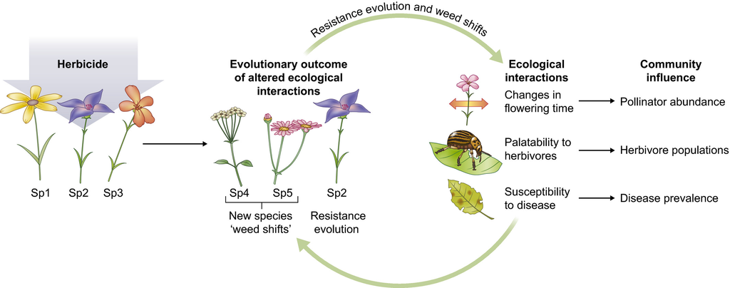

**Figure 1**

Potential eco-evolutionary dynamics within an agricultural weed community.

It is important to note that alterations in community dynamics can be caused by the initial use of the herbicide – which need not include resistance evolution. For example, a weed community that is exposed to an herbicide for the first time exhibits ‘weed shifts’ in which a new community of weeds – potentially those exhibiting low-level resistance, or communities that exhibit herbicide avoidance traits (for example early/late germination) – may establish (as shown in Fig. 1; Culpepper, 2006; Owen, 2008). This restructuring of the community alone has strong potential to alter ecological interactions. If herbicide application is consistent and appreciable levels of genetic variation underlying traits exist, resistance may eventually evolve within the weed species, and further propel community dynamics.

Tests of eco-evolutionary dynamics require both observational studies and experimental manipulations (Strauss, 2014; Hendry, 2016). Some relevant experimental designs for testing potential eco-evolutionary feedbacks using the plant/herbicide model are: (1) an experimental evolution approach in which the researcher applies herbicide and assesses both evolutionary and ecological changes over time at the community level; (2) manipulating the genotypes present and assessing the potential for different ecological interactions (introducing mostly resistant individuals into a community with susceptible individuals used in a control community); and (3) using a genotype ‘mismatch’ approach in which ancestral genotypes (in this case, susceptible lineages of a species) are planted in a common garden community along with genotypes that have been allowed to diverge, then assessing the potential for changed ecological interactions, which may stem from declines or changes in the presence of particular species, or alterations in species’ visitation patterns or population growth rates. These suggested designs will help determine if evolutionary change leads to altered ecological interactions, but will not test for eco-evolutionary feedbacks, as this requires showing a causal link between changed ecological interactions and subsequent evolution (Yoshida *et al*., 2003; Turcotte *et al*., 2013). To do this, one could effectively prevent evolution, or manipulate evolvability – potentially by replacing genotypes during the course of a multiple-year experiment – and then compare with treatments in which evolution is allowed to occur (Yoshida *et al*., 2003; Turcotte *et al*., 2013).

Overall, the plant/herbicide model system presents a unique opportunity for researchers to examine multistage eco-evolutionary dynamics. Pairing observations of agricultural weed communities, sampling seeds from weed populations before the onset of a new herbicide, and setting up manipulative experimental designs will allow researchers to disentangle the direct ecological effects of the herbicide application itself from resistance evolution, subsequently altered ecological interactions, and the potential for unpredictable evolutionary feedbacks.

## VI. Conclusion

Studies of herbicide-resistant weeds have yielded key insights in evolution and ecology including, but not limited to, the identification of mutations responsible for adaptive phenotypes, the parallel nature of convergent adaptation, the influence of epistatic interactions among loci, pleiotropic effects of novel mutations (fitness costs), and the potential for co-evolution and/or tradeoffs among traits. Additionally, the plant/herbicide model has been used to assess the influence of variable selection regimes on the likelihood and rate of resistance evolution, as well as the potential for the evolution of ‘generalist’ resistance. As I hope to have demonstrated with this review, there is no lack of opportunity within the study of herbicide resistance evolution. There are plenty of plant/herbicide models available for study and there are similarly many exciting, novel questions yet to be addressed. I have attempted to highlight outstanding questions throughout this work, and I further develop them in Table 1 and Box 2.

Table 1. A noncomprehensive sample of questions addressing various aspects of herbicide resistance evolution

[output not shown]

- These questions are relevant to management and similarly address outstanding questions in ecology and/or evolution. Performing the suggested field experiments in the context of a cropping system would be ideal and allow for relevant practical conclusions.

Two broad areas that I believe are particularly important – with relevance to both management and ecology and evolution – are the study of NTSR mechanisms (as discussed in depth by Délye, 2013), and the study of resistance evolution in an eco-evolutionary, community framework. We know remarkably little information about the biology underlying the various traits that may confer NTSR or their frequency among herbicide-resistant species (expanded on in Table 1), and we know even less about the genetics underlying these traits. NTSR mechanisms may work alone or in concert with other NTSR mechanisms to confer resistance; perhaps they work in concert with TSR mechanisms. Are the different types of defense redundant, or do they work additively? Beyond understanding the biology of NTSR for weed control purposes, the examination of how different forms of defense may trade off, or not, is of broad interest in evolutionary ecology. Furthermore, we have strikingly little insight into the whole-community framework within which resistance evolves – which community members are evolutionarily altered as a result of resistance evolution in weeds?

The importance of studying all components of weed adaptation to herbicide cannot be overemphasized. Pressing population size increases, global climate change, and reductions in available farmland all place the productivity of crops at a premium (Vandermeer *et al*., 2018). Given the negative influence of weeds on crop yield, the study of weed adaptation should figure heavily into every modern research agenda. Here I have attempted to emphasize that the plant/herbicide model is uniquely poised to address questions in evolution and ecology more broadly. Ideally, research programs using the plant/herbicide model will be designed to perform a dual purpose – they will address novel evolutionary and ecological questions as well as identify the factors that act to maintain or predict resistance evolution in the field.

## Acknowledgements

I thank TL Ashman, K Dlugosch, Pétra Vande Zande, Luis Zaman, four anonymous reviewers, and Lynda Delph for providing valuable feedback on this manuscript. Funding was provided by USDA-NIFA (078196).

## Citing Literature

[figure not shown]

[Volume223, Issue1](https://nph.onlinelibrary.wiley.com/toc/14698137/2019/223/1)

July 2019

Pages 68-82

[figure not shown]

### Recommended

[figure not shown]